# A Shallow Dive into Time Series: Analysis of Local Restaurant Data Using R

Kenna Schoeler

#### Introduction and Motivation:

The purpose of this article is to highlight time series analysis in R. It is motivated by personal curiousity, and a desire to suggest that small businesses can gain from employing open source statistical computing software. Currently, few restaurants use R or any other readily available statistical software to analyze their data. Instead many use subscriptions to services that may preform basic analysis such as averaging and then display that information in basic, though visually appealing visualizations. It is worth proposing that there can be deeper and more meaningful conclusions made about the health of a small business when we take data into our own hands and begin to explore it on our own. This article will provide a transparent how-to example for anyone (with or without a statistics background) interested in jumping straight in.

#### Background:

According to the department of statistics at Stockholm University the beginnings of time series analysis date back to the 1920s and 1930s when George Yule, J. Walker, Karl Pearson, and others worked to develop and greatly influence auto regressive modelling. Later in the 1970s, the book: “Time Series Analysis” by G.E.P. Box and G.M. Jenkins was published and within it, the authors gave a more completed method for time series modelling than had otherwise been published before. Many different techniques for this type of analysis have since developed, including the ARCH and GARCH procedures for parametarization of non constant variance, however my focus here will exclude such methods.

A time series can be understood as a set of data that is recorded at regular intervals, and a couple good examples are the height measurement of tidal waves or the values recorded at the close of the stock market. There is plenty to know about time series, and I do not hope to cover even a fraction of the available information, but rather provide a taste for this type of analysis.

Let’s start with the restaurant’s data for seated covers. Consider the number of covers a restaurant serves to be the number of meals. The difference between an entree and a meal is very similar to the difference between a entree and a cover. One cover includes everything that accompanies an entree. Suppose a guest orders two glasses of white wine, a salad to start, an entree of salmon, and a piece of chocolate cake for dessert. Everything the guest ordered is counted as part of one cover. The cover includes all extras ordered along with one entree. The number of seated covers a restaurant experiences is a good measure of its popularity because it is representative of how many guests were received by the restaurant.

#### R Code Examples:

Throughout this article I will provide the code used to arrive at any of my plots and charts.

In the following code I read in the data from a csv file using the `read.csv()` function. I took data from the restaurant and put it in a tabular format to prepare it for this analysis. Depending on the format of your data you may need clean it up to be sure that it is in a format where each point in time has a corresponding entry.

Here is an example portion of the data:

```r
# Read in the data (seated_covers stands for the number of "seated covers" or
# you can consider this "number of guests" the restaurant took in every month
# over the course of nearly 10 years)
seated_covers <- read.csv(
  "~/Dropbox/stat133/stat133-hws-fall17/post02/seated_cvrs.csv")

tail(seated_covers)
```

```
##        date seated_cvrs
## 115  7/1/17         328
## 116  8/1/17         386
## 117  9/1/17         467
## 118 10/1/17         215
## 119 11/1/17          NA
## 120 12/1/17          NA
```

Although my data is represented by monthly entries, it is important to note that a time series can be any set of data recorded at a regular interval down to milliseconds even.

Let’s begin the analysis:

```r
#install.packages("tseries")
library(tseries)
```

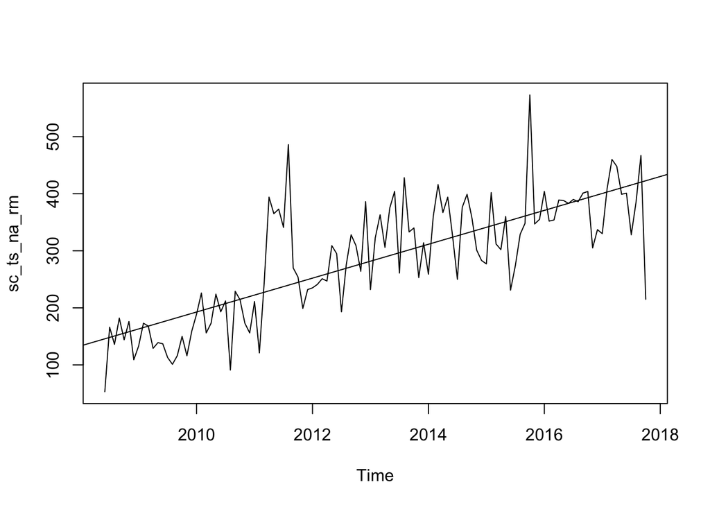

```r
# To continue, make seated_covers a time series object
sc_ts <- ts(seated_covers$seated_cvrs, frequency = 12, start = 2008)
sc_ts_na_rm <- na.remove(sc_ts)

# Plot seated_covers to get an idea of how the trend looks
plot(sc_ts_na_rm)

# Add a line to observe the mean
abline(reg = lm(sc_ts_na_rm~time(sc_ts_na_rm)))
```

```r
# Look at the summary info for the data
summary(sc_ts_na_rm)
```

```
##    Min. 1st Qu.  Median    Mean 3rd Qu.    Max.
##    53.0   199.0   301.0   284.3   367.0   573.0
```

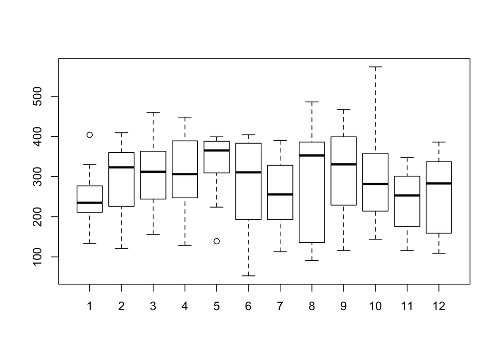

```r
# Now use a box plot to check seasonality of the data
boxplot(sc_ts~cycle(sc_ts))
```

This first plot gives us a sense of how the business trend looks in general and the box plot gives us an idea for the seasonal fluctuations the restaurant experiences. 1-12 represent the months of the year and we can see that the month of May (5) is consistently a month that sees a high number of guests to the restaurant. This box plot also shows us outlier months where the number of guests visiting the restaurant happen to be exceptionally high or exceptionally low. We continue by adjusting the time series data in order to prepare it for use in the forecasting phase. This requires making the mean and the variance constant, known as making the data “stationary”.

Stationarity is important because when a sequence is stationary a lot of properties that work for independent random variables (ie Law of Large Numbers, and Central Limit Theorem) also work for the time series data. Sationarity is defined uniquely in that a sequence of data can only be stationary or not stationary. Similar to independence being defined uniquely. We need stationarity so that the model we create to describe the data does not vary in accuracy at different points in time as it would have had we not differenced the data.

So her is the code for this process:

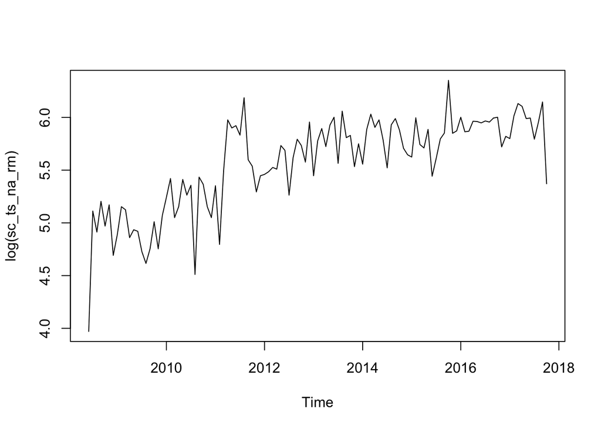

```r
# Do this by taking the log of the data within sc_ts, and plotting what you find
# to see if the plot becomes stationary
plot(log(sc_ts_na_rm))
```

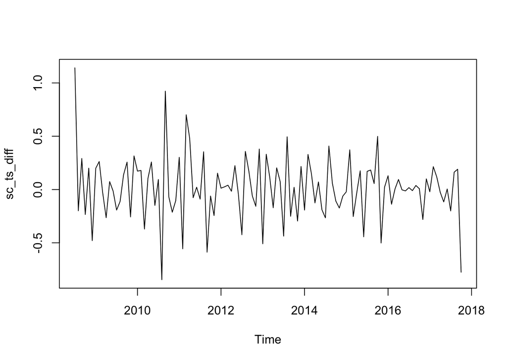

```r
# We can see that this plot is not stationary (does not have a constant mean
# with equal variance) so we change that!

# Now try to difference the plot to give it these qualities.
sc_ts_diff <- diff(log(sc_ts_na_rm))


# Here we can see that we seemingly have stationarity
plot(sc_ts_diff)
```

We continue on by testing out different known time series methods beginning with ARIMA because it is known to have the smallest mean-squared forecast error, but an AR model (of the same class as ARIMA) or any other linear, univariate, or fixed parameter may also work. It is important to notice that by taking the log of the data, we have that the time series becomes additive rather than multiplicative. This should be kept in mind depending on how you would like to procede with modelling.

As we explore an ARIMA method, which stands for (Auto-Regressive Integrated Moving Average) we keep in mind that there are many ways to begin this type of analysis and ARIMA is one of many.